# MA50258 Applied Statistics: Coursework 2

Xiaomei Ge

```r
brexit <- read_csv("https://people.bath.ac.uk/kai21/MA50258/data/brexit.csv")
```

**Explore the data**

The scatter plot shows shows agreement between fits is not that bad, the linear fit can well describe the relationship between average wealth and average BL when average wealth is in 30-55, however, linear fits overestimate the BL when average wealth is above 55 and below 30

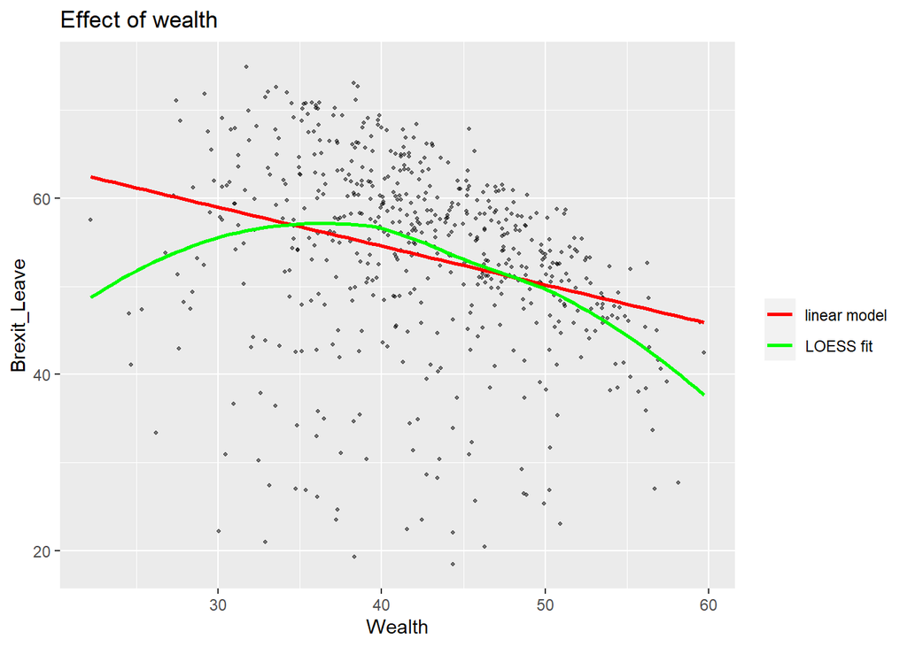

```r
London<-
  brexit%>%
    filter(Region!= "London")


#Loess fit empirical fit

         brexit %>%
  ggplot(aes(x =Wealth ,
             y = BREXITLeave)) +
    geom_point(alpha = 0.5,
               size  = 0.8)+
      geom_smooth(aes(col = "linear model"),
                  method  = "lm",
                  se = F,
                  linewidth = 1) +
  geom_smooth(aes(col = "LOESS fit"),
                  method  = "loess",
                  se = F,
                  linewidth = 1)+
        labs(x = "Wealth",
             y = "Brexit_Leave",
             title="Effect of wealth")+
          scale_colour_manual("",
                              values = c("linear model"= "red", "LOESS fit" = "green"))
```

The scatter plot shows the fits virtually same for average bornUk above 60, however, the linear fit underestimates the average BL for small percentage in Born in UK, the lower average is quite different from Loess fit is might because of London(more region details later)

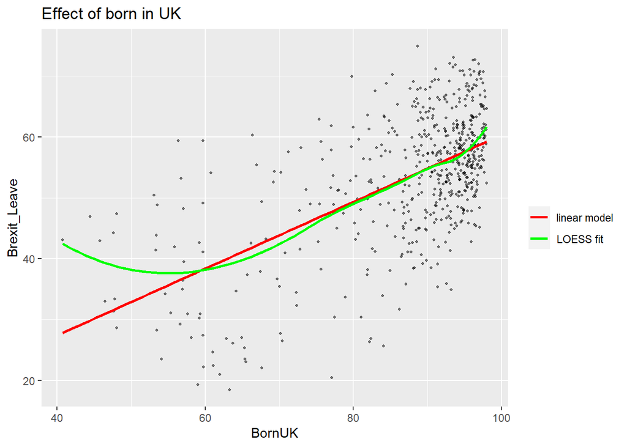

```r
       brexit %>%
  ggplot(aes(x =BornUK,
             y = BREXITLeave)) +
    geom_point(alpha = 0.5,
               size  = 0.8)+
      geom_smooth(aes(col = "linear model"),
                  method  = "lm",
                  se = F,
                  linewidth = 1) +
  geom_smooth(aes(col = "LOESS fit"),
                  method  = "loess",
                  se = F,
                  linewidth = 1)+
        labs(x = "BornUK",
             y = "Brexit_Leave",
             title="Effect of born in UK")+
          scale_colour_manual("",
                              values = c("linear model"= "red", "LOESS fit" = "green"))
```

The linear model fit differs substantially from the Loess fit, it is obvious that relationship between over65 and BL is non-linear

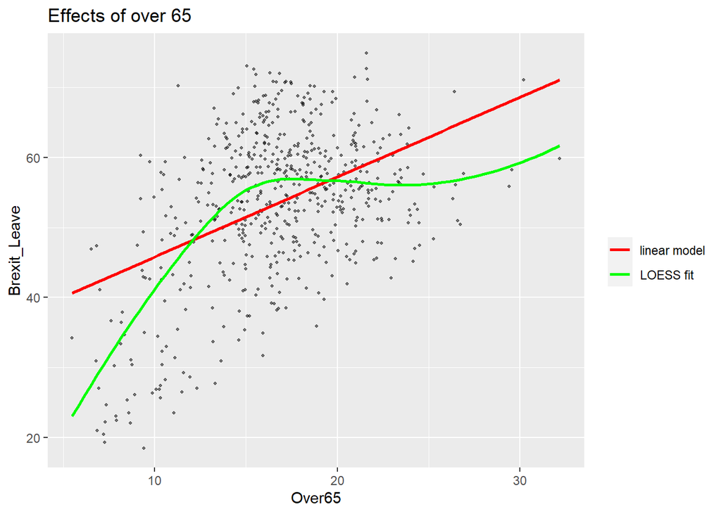

```r
         brexit %>%
  ggplot(aes(x =over65,
             y = BREXITLeave)) +
    geom_point(alpha = 0.5,
               size  = 0.8)+
      geom_smooth(aes(col = "linear model"),
                  method  = "lm",
                  se = F,
                  linewidth = 1) +
  geom_smooth(aes(col = "LOESS fit"),
                  method  = "loess",
                  se = F,
                  linewidth = 1)+
        labs(x = "Over65",
             y = "Brexit_Leave",
             title="Effects of over 65")+
          scale_colour_manual("",
                              values = c("linear model"= "red", "LOESS fit" = "green"))
```

**Explore interaction**

The plot illustrates that weak interaction between wealth and regions apart from London and wales, the trend in London is substantially different from other regions, the overall trend is the richer the lower BL

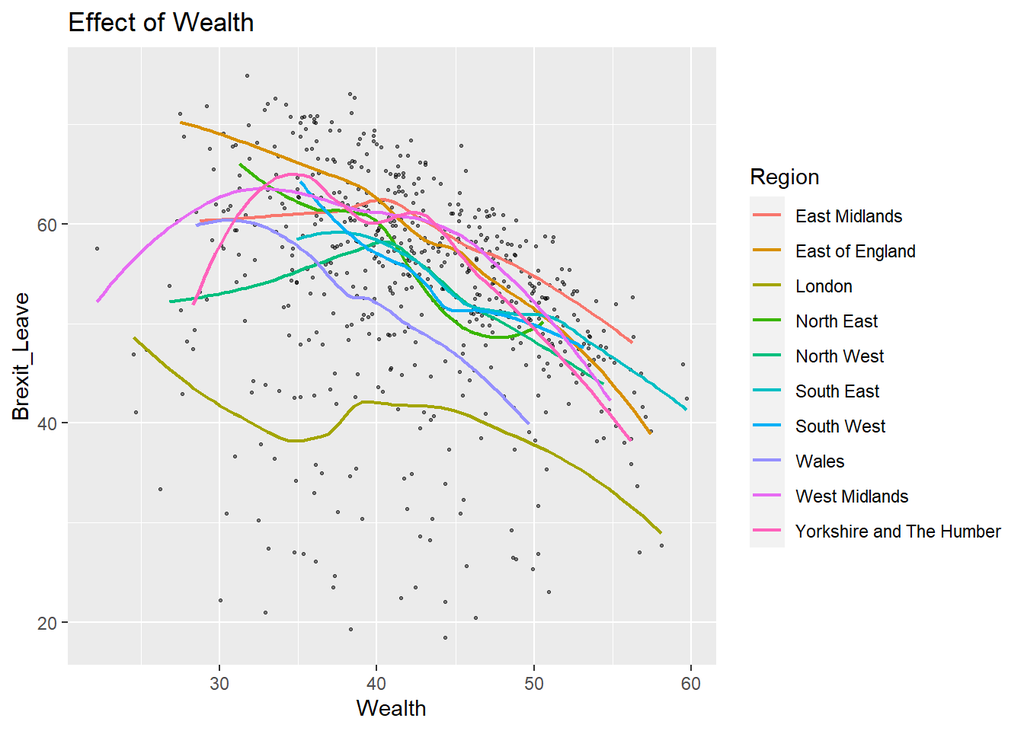

```r
library(modelr)


plot_group_by_year <-
  brexit %>%
    mutate(Region = factor(Region)) %>%
      ggplot(aes(x     = Wealth,
                 y     = BREXITLeave,
                 group = Region)) +
        geom_point(alpha = 0.5,
                   size  = 0.5) +
          geom_smooth(aes(col = Region),
                      method    = "loess",
                      se        = F,
                      formula   = y ~ x,
                      linewidth =0.8) +
                labs(x   = "Wealth",
                     y   = "Brexit_Leave",
                     title="Effect of Wealth")

plot_group_by_year
```

The interaction between BornUk and BL is not strong except London, London have a quite different pattern, London has less percentage people born in Uk which means London is more international than other region, the overall pattern is the higher the proportion born in the UK, the higher BL

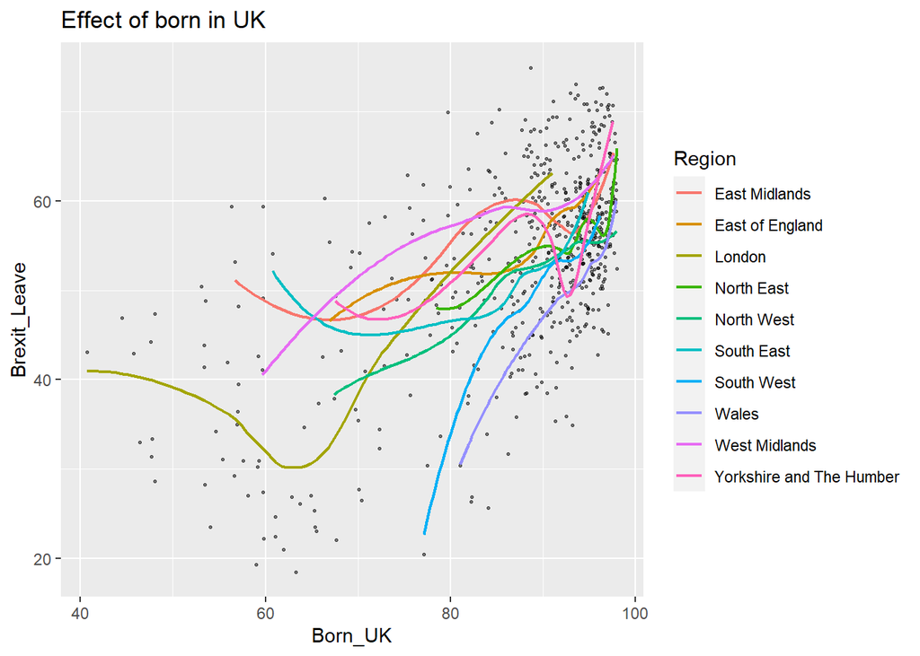

```r
plot_group_by_year <-
  brexit %>%
    mutate(Region = factor(Region)) %>%
      ggplot(aes(x     = BornUK,
                 y     = BREXITLeave,
                 group = Region)) +
        geom_point(alpha = 0.5,
                   size  = 0.5) +
          geom_smooth(aes(col = Region),
                      method    = "loess",
                      se        = F,
                      formula   = y ~ x,
                      linewidth =0.8) +
                labs(x   = "Born_UK",
                     y   = "Brexit_Leave",
                     title="Effect of born in UK")

plot_group_by_year
```

The graph shows the weak interaction between over65 and regions apart from London and south west, the overall data trend is that BL concentrate in constituency with around 18% of people over65

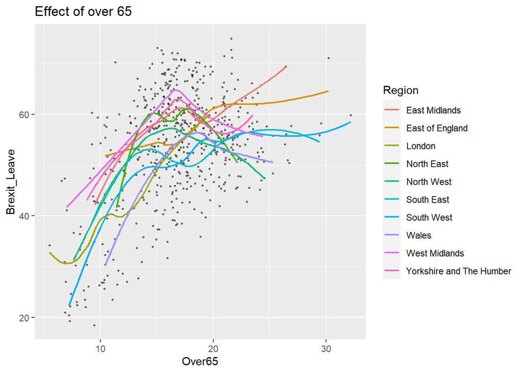

```r
plot_group_by_year <-
  brexit %>%
    mutate(Region = factor(Region)) %>%
      ggplot(aes(x     = over65,
                 y     = BREXITLeave,
                 group = Region)) +
        geom_point(alpha = 0.5,
                   size  = 0.5) +
          geom_smooth(aes(col = Region),
                      method    = "loess",
                      se        = F,
                      formula   = y ~ x,
                      linewidth =0.8) +
                labs(x   = "Over65",
                     y   = "Brexit_Leave",
                     title="Effect of over 65")

plot_group_by_year
```

From the exploratory analysis above, I found BornUk and over65 have non-linear relationships with brexit leave, wealth and brexit shows more linear relationship for wealth in 30-55, I will try polynomial fit to find model, the plots bellow is my exploratory process. from the plots, quadratic and cubic are virtually good.

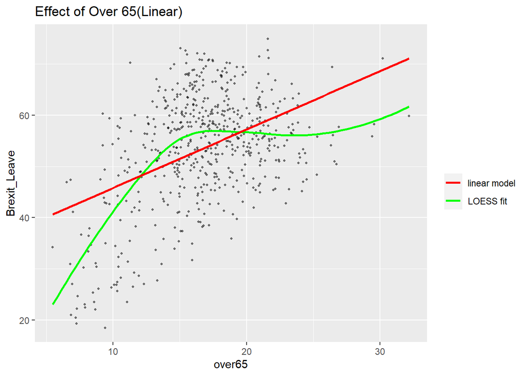

```r
 base_plot<-  brexit %>%
  ggplot(aes(x =over65,
             y = BREXITLeave)) +
    geom_point(alpha = 0.5,
               size  = 0.8)+
      geom_smooth(aes(col = "LOESS fit"),
                  method  = "loess",
                  formula = y~ x,
                  se = F,
                  linewidth = 1)


base_plot +
  geom_smooth(aes(col = "linear model"),
                  method  = "lm",
                  se = F,
                  linewidth = 1)+
        labs(x = "over65",
             y = "Brexit_Leave",
             title="Effect of Over 65(Linear)")+
          scale_colour_manual("",
                              values = c("linear model"= "red", "LOESS fit" = "green"))
```

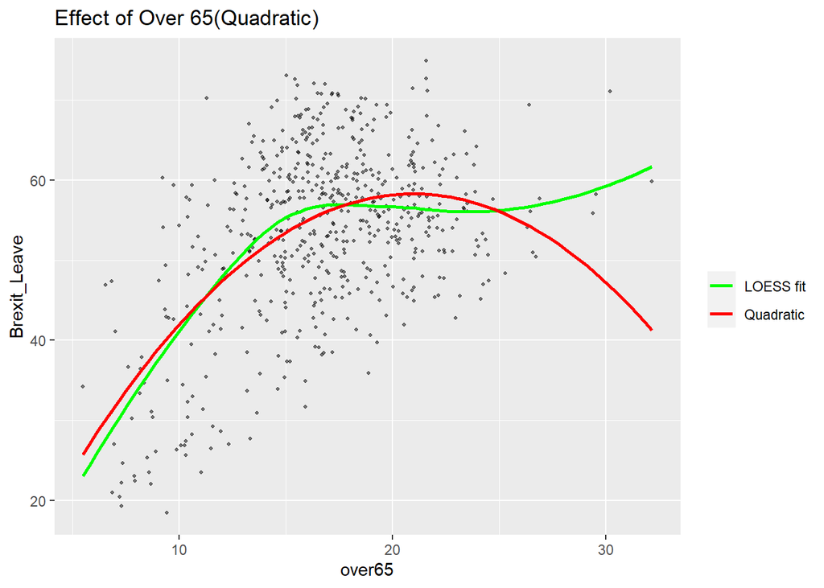

```r
base_plot +
  geom_smooth(aes(col = "Quadratic"),
                  method  = "lm",
                  formula = y ~ x+ I(x^2),
                  se = F,
                  linewidth = 1)+
        labs(x = "over65",
             y = "Brexit_Leave",
             title="Effect of Over 65(Quadratic)")+
          scale_colour_manual("",
                              values = c("Quadratic"= "red", "LOESS fit" = "green"))
```

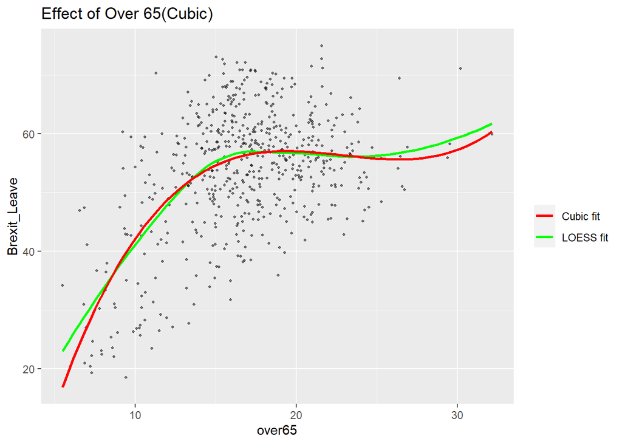

```r
base_plot +
  geom_smooth(aes(col = "Cubic fit"),
                  method  = "lm",
                  formula = y ~ x+ I(x^2)+I(x^3),
                  se = F,
                  linewidth = 1)+
        labs(x = "over65",
             y = "Brexit_Leave",
             title="Effect of Over 65(Cubic)")+
          scale_colour_manual("",
                              values = c("Cubic fit"= "red", "LOESS fit" = "green"))
```

**Build Models**

From the analysis above, here are some information that help me build my model: 1.There are interactions between some of regions and bornUK, over65, Wealth respectfully. 2.over65 have non-linear relationship with BL(Brexit Leave) 3. large percentage of born UK have close linear relationship with BL

based on the information above, after finding non-linear relationships, I use plots of polynomial fit to check if each predictor has virtually fit well with data(Loess as reference), if the trend of polynomial fit is very close, I will choose that polynomial as my candidate model. after checking interaction between variables by ggplot, I add interaction to see if the interaction influence my models. I use AIC and F hypothesis test to pick the best model, The smaller AIC, the model have more good balance between complexity and residual.

I finally get three models that i think that are best three.

Model1
$$E[\verb|Brexit_Leave||\verb|over65,wealth,BornUk,Region|]=\alpha_0
+ \alpha_1 \,\verb|over65|+\alpha_2 \,\verb|over65^2|+\alpha_3
\,\verb|Wealth|+\alpha_4 \,\verb|BornUK|+\alpha_5
\,\verb|Region|$$
Model2
$$E[\verb|Brexit_Leave||\verb|over65,wealth,BornUk,Region|]=\gamma_0
+ \gamma_1 \,\verb|over65|+\gamma_2 \,\verb|over65^2|+\gamma_3
\,\verb|Wealth|+\gamma_4 \,\verb|BornUK|+\gamma_5
\,\verb|Region|+\gamma_6 \,\verb|Region*over65^2|$$
Model3
$$E[\verb|Brexit_Leave||\verb|over65,wealth,BornUk,Region|]=\beta_0
+ \beta_1 \,\verb|over65|+\beta_2 \,\verb|over65^2|+\beta_3
\,\verb|Wealth|+\beta_4 \,\verb|BornUK|+\beta_5 \,\verb|Region|+\beta_6
\,\verb|Region*Wealth|+\beta_7 \,\verb|BornUk*Wealth|$$

Here is the AIC results of three models

```r
mod1 <- lm(BREXITLeave~over65+Wealth+BornUK+Region+I(over65^2),brexit)

mod2 <-lm(BREXITLeave~over65+Wealth+BornUK+Region*I(over65^2),brexit)

mod3 <- lm(BREXITLeave~over65+I(over65^2)+Wealth+BornUK+Region+Wealth*BornUK+Wealth*Region,brexit)

cat("AIC of Model1:",extractAIC(mod1)[2],"\n")
```

```
## AIC of Model1: 1985.909
```

```r
cat("AIC of Model2:",extractAIC(mod2)[2],"\n")
```

```
## AIC of Model2: 1981.837
```

```r
cat("AIC of Model3:",extractAIC(mod3)[2],"\n")
```

```
## AIC of Model3: 1968.26
```

Hypothesis Test for my Model1:
$$H_0:\,
\alpha_0=\alpha_1=\alpha_2=\alpha_3=\alpha_4=\alpha_5=0
\qquad \mbox{vs} \qquad H_1:\,\alpha_1\neq 0, \alpha_2\neq
0,\alpha_3\neq 0,\alpha_4\neq 0,\alpha_5\neq 0$$

From the ANOVA table, the results of F test shows that null hypothesis test above should be rejected which means that all the independent variables in model1 have significant relationship with response variable(BL)

```r
anova(mod1)
```

```
## Analysis of Variance Table
##
## Response: BREXITLeave
##              Df  Sum Sq Mean Sq F value    Pr(>F)
## over65        1 13176.6 13176.6 421.795 < 2.2e-16 ***
## Wealth        1 12875.1 12875.1 412.144 < 2.2e-16 ***
## BornUK        1 11878.1 11878.1 380.228 < 2.2e-16 ***
## Region        9  7415.0   823.9  26.373 < 2.2e-16 ***
## I(over65^2)   1  3981.2  3981.2 127.443 < 2.2e-16 ***
## Residuals   559 17462.8    31.2
## ---
## Signif. codes:  0 '***' 0.001 '**' 0.01 '*' 0.05 '.' 0.1 ' ' 1
```

Coefficient table for model1

Interpretation for coefficient From the table, North East, North West,South West and Wales have strong effect on BL. fix other variables, increase one percentage of wealth, one percent of leave votes in the constituency will decrease. fix other variables, increase one percentage of people born in UK, 0.5 percent of leave votes in the constituency will increase.

```r
summary(mod1)
```

```
##
## Call:
## lm(formula = BREXITLeave ~ over65 + Wealth + BornUK + Region +
##     I(over65^2), data = brexit)
##
## Residuals:
##      Min       1Q   Median       3Q      Max
## -20.3500  -2.7572   0.5382   3.5799  18.5736
##
## Coefficients:
##                                 Estimate Std. Error t value Pr(>|t|)
## (Intercept)                      8.79634    3.57896   2.458   0.0143 *
## over65                           5.00882    0.42809  11.700  < 2e-16 ***
## Wealth                          -1.02102    0.04016 -25.425  < 2e-16 ***
## BornUK                           0.50978    0.04883  10.440  < 2e-16 ***
## RegionEast of England            0.72369    1.11003   0.652   0.5147
## RegionLondon                    -0.21928    1.37456  -0.160   0.8733
## RegionNorth East                -7.02196    1.34978  -5.202 2.77e-07 ***
## RegionNorth West                -7.67461    1.05654  -7.264 1.27e-12 ***
## RegionSouth East                -0.06678    1.05437  -0.063   0.9495
## RegionSouth West                -4.91962    1.13696  -4.327 1.79e-05 ***
## RegionWales                    -13.08125    1.23394 -10.601  < 2e-16 ***
## RegionWest Midlands             -1.52420    1.10620  -1.378   0.1688
## RegionYorkshire and The Humber  -2.78003    1.12748  -2.466   0.0140 *
## I(over65^2)                     -0.12562    0.01113 -11.289  < 2e-16 ***
## ---
## Signif. codes:  0 '***' 0.001 '**' 0.01 '*' 0.05 '.' 0.1 ' ' 1
##
## Residual standard error: 5.589 on 559 degrees of freedom
## Multiple R-squared:  0.7385, Adjusted R-squared:  0.7325
## F-statistic: 121.5 on 13 and 559 DF,  p-value: < 2.2e-16
```

Hypothesis Test for my Model2:
$$H_0:\,
\gamma_0=\gamma_1=\gamma_2=\gamma_3=\gamma_4=\gamma_5=\gamma_6=0\
\qquad \mbox{vs} \qquad H_1:\,\gamma_1\neq 0, \gamma_2\neq
0,\gamma_3\neq 0,\gamma_4\neq 0,\gamma_5\neq
0,\gamma_6\neq0$$

form the ANOVA table, the results of F test shows that null hypothesis above test should be rejected which means that all the independent variables in model1 have significant relationship with response variable(BL)

```r
anova(mod2)
```

```
## Analysis of Variance Table
##
## Response: BREXITLeave
##                     Df  Sum Sq Mean Sq  F value Pr(>F)
## over65               1 13176.6 13176.6 431.3014 <2e-16 ***
## Wealth               1 12875.1 12875.1 421.4331 <2e-16 ***
## BornUK               1 11878.1 11878.1 388.7978 <2e-16 ***
## Region               9  7415.0   823.9  26.9678 <2e-16 ***
## I(over65^2)          1  3981.2  3981.2 130.3153 <2e-16 ***
## Region:I(over65^2)   9   659.9    73.3   2.3999 0.0113 *
## Residuals          550 16803.0    30.6
## ---
## Signif. codes:  0 '***' 0.001 '**' 0.01 '*' 0.05 '.' 0.1 ' ' 1
```

Coefficient table for model2

```r
summary(mod2)
```

```
##
## Call:
## lm(formula = BREXITLeave ~ over65 + Wealth + BornUK + Region *
##     I(over65^2), data = brexit)
##
## Residuals:
##      Min       1Q   Median       3Q      Max
## -20.8494  -2.7986   0.3868   3.4598  15.8861
##
## Coefficients:
##                                              Estimate Std. Error t value
## (Intercept)                                 14.688852   4.671898   3.144
## over65                                       4.486313   0.483074   9.287
## Wealth                                      -1.047249   0.041685 -25.123
## BornUK                                       0.495086   0.049408  10.020
## RegionEast of England                        3.989798   2.924860   1.364
## RegionLondon                                -3.758481   2.932271  -1.282
## RegionNorth East                            -2.226140   4.752009  -0.468
## RegionNorth West                            -7.035602   2.902083  -2.424
## RegionSouth East                             4.532196   2.751019   1.647
## RegionSouth West                            -6.968378   3.121530  -2.232
## RegionWales                                -11.443569   3.637072  -3.146
## RegionWest Midlands                         -2.298950   3.086813  -0.745
## RegionYorkshire and The Humber              -4.487319   3.169204  -1.416
## I(over65^2)                                 -0.107541   0.014727  -7.302
## RegionEast of England:I(over65^2)           -0.010229   0.008652  -1.182
## RegionLondon:I(over65^2)                     0.021620   0.011382   1.900
## RegionNorth East:I(over65^2)                -0.015320   0.014767  -1.037
## RegionNorth West:I(over65^2)                -0.002234   0.008884  -0.251
## RegionSouth East:I(over65^2)                -0.014556   0.008251  -1.764
## RegionSouth West:I(over65^2)                 0.004047   0.008600   0.471
## RegionWales:I(over65^2)                     -0.005154   0.010263  -0.502
## RegionWest Midlands:I(over65^2)              0.002220   0.009410   0.236
## RegionYorkshire and The Humber:I(over65^2)   0.005926   0.009913   0.598
##                                            Pr(>|t|)
## (Intercept)                                 0.00176 **
## over65                                      < 2e-16 ***
## Wealth                                      < 2e-16 ***
## BornUK                                      < 2e-16 ***
## RegionEast of England                       0.17309
```

[output cut: 9 more lines]

```
## RegionEast of England:I(over65^2)           0.23763
## RegionLondon:I(over65^2)                    0.05801 .
## RegionNorth East:I(over65^2)                0.29997
## RegionNorth West:I(over65^2)                0.80153
## RegionSouth East:I(over65^2)                0.07826 .
## RegionSouth West:I(over65^2)                0.63815
## RegionWales:I(over65^2)                     0.61573
## RegionWest Midlands:I(over65^2)             0.81355
## RegionYorkshire and The Humber:I(over65^2)  0.55021
## ---
## Signif. codes:  0 '***' 0.001 '**' 0.01 '*' 0.05 '.' 0.1 ' ' 1
##
## Residual standard error: 5.527 on 550 degrees of freedom
## Multiple R-squared:  0.7484, Adjusted R-squared:  0.7384
## F-statistic: 74.37 on 22 and 550 DF,  p-value: < 2.2e-16
```

Hypothesis Test for my Model3:
$$H_0:\,
\beta_0=\beta_1=\beta_2=\beta_3=\beta_4=\beta_5=\beta_6=\beta_7=0\
\qquad \mbox{vs} \qquad H_1:\,\beta_1\neq 0, \beta_2\neq 0,\beta_3\neq
0,\beta_4\neq 0,\beta_5\neq 0,\beta_6\neq0,\beta_7\neq0$$
Form the ANOVA table, the results of F test shows that null hypothesis above test should be rejected which means that all the independent variables in model1 have significant relationship with response variable(BL)

```r
anova(mod3)
```

```
## Analysis of Variance Table
##
## Response: BREXITLeave
##                Df  Sum Sq Mean Sq  F value    Pr(>F)
## over65          1 13176.6 13176.6 442.3817 < 2.2e-16 ***
## I(over65^2)     1  7576.0  7576.0 254.3512 < 2.2e-16 ***
## Wealth          1 19069.0 19069.0 640.2078 < 2.2e-16 ***
## BornUK          1  2539.4  2539.4  85.2567 < 2.2e-16 ***
## Region          9  6965.0   773.9  25.9821 < 2.2e-16 ***
## Wealth:BornUK   1   392.1   392.1  13.1656 0.0003118 ***
## Wealth:Region   9   718.4    79.8   2.6798 0.0047097 **
## Residuals     549 16352.3    29.8
## ---
## Signif. codes:  0 '***' 0.001 '**' 0.01 '*' 0.05 '.' 0.1 ' ' 1
```

Coefficient table for model3

```r
summary(mod3)
```

```
##
## Call:
## lm(formula = BREXITLeave ~ over65 + I(over65^2) + Wealth + BornUK +
##     Region + Wealth * BornUK + Wealth * Region, data = brexit)
##
## Residuals:
##      Min       1Q   Median       3Q      Max
## -19.5605  -2.8433   0.4153   3.3489  21.6866
##
## Coefficients:
##                                         Estimate Std. Error t value Pr(>|t|)
## (Intercept)                            55.739383  16.355224   3.408 0.000702
## over65                                  5.209896   0.422720  12.325  < 2e-16
## I(over65^2)                            -0.133774   0.011079 -12.075  < 2e-16
## Wealth                                 -2.354526   0.424869  -5.542 4.65e-08
## BornUK                                 -0.028027   0.178416  -0.157 0.875235
## RegionEast of England                  15.297204   7.569474   2.021 0.043774
## RegionLondon                           -7.609144   7.733118  -0.984 0.325564
## RegionNorth East                       -1.812054  10.388634  -0.174 0.861595
## RegionNorth West                      -18.593083   6.769593  -2.747 0.006220
## RegionSouth East                       -4.604014   7.100047  -0.648 0.516966
## RegionSouth West                      -10.184000   9.238395  -1.102 0.270790
## RegionWales                           -20.914799   9.332135  -2.241 0.025415
## RegionWest Midlands                    -4.936702   6.715406  -0.735 0.462574
## RegionYorkshire and The Humber          5.540410   7.007612   0.791 0.429503
## Wealth:BornUK                           0.014826   0.004532   3.271 0.001137
## Wealth:RegionEast of England           -0.313074   0.171042  -1.830 0.067733
## Wealth:RegionLondon                     0.207856   0.186069   1.117 0.264445
## Wealth:RegionNorth East                -0.127418   0.253632  -0.502 0.615605
## Wealth:RegionNorth West                 0.269877   0.158582   1.702 0.089356
## Wealth:RegionSouth East                 0.111577   0.157282   0.709 0.478372
## Wealth:RegionSouth West                 0.127718   0.207151   0.617 0.537791
## Wealth:RegionWales                      0.214215   0.229465   0.934 0.350952
## Wealth:RegionWest Midlands              0.084585   0.158784   0.533 0.594454
## Wealth:RegionYorkshire and The Humber  -0.201296   0.164118  -1.227 0.220524
##
## (Intercept)                           ***
## over65                                ***
## I(over65^2)                           ***
## Wealth                                ***
```

[output cut: 11 more lines]

```
## Wealth:RegionEast of England          .
## Wealth:RegionLondon
## Wealth:RegionNorth East
## Wealth:RegionNorth West               .
## Wealth:RegionSouth East
## Wealth:RegionSouth West
## Wealth:RegionWales
## Wealth:RegionWest Midlands
## Wealth:RegionYorkshire and The Humber
## ---
## Signif. codes:  0 '***' 0.001 '**' 0.01 '*' 0.05 '.' 0.1 ' ' 1
##
## Residual standard error: 5.458 on 549 degrees of freedom
## Multiple R-squared:  0.7552, Adjusted R-squared:  0.7449
## F-statistic: 73.62 on 23 and 549 DF,  p-value: < 2.2e-16
```

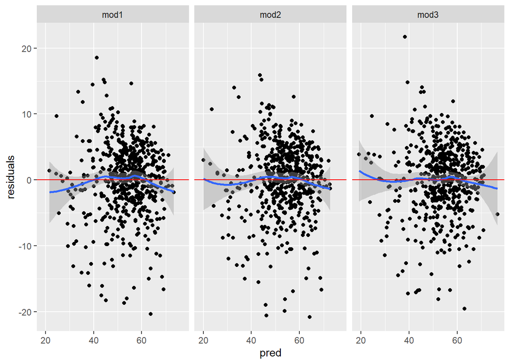

```r
BL_pred <-
 brexit%>%
 gather_predictions(mod1,mod2,mod3) %>%
 mutate(residuals = BREXITLeave- pred)

BL_pred %>%
 ggplot(aes(pred,residuals)) +
 geom_point() +
 geom_smooth(se = T) +
 geom_hline(yintercept = 0, col = "red") +
 facet_wrap(~ model)
```

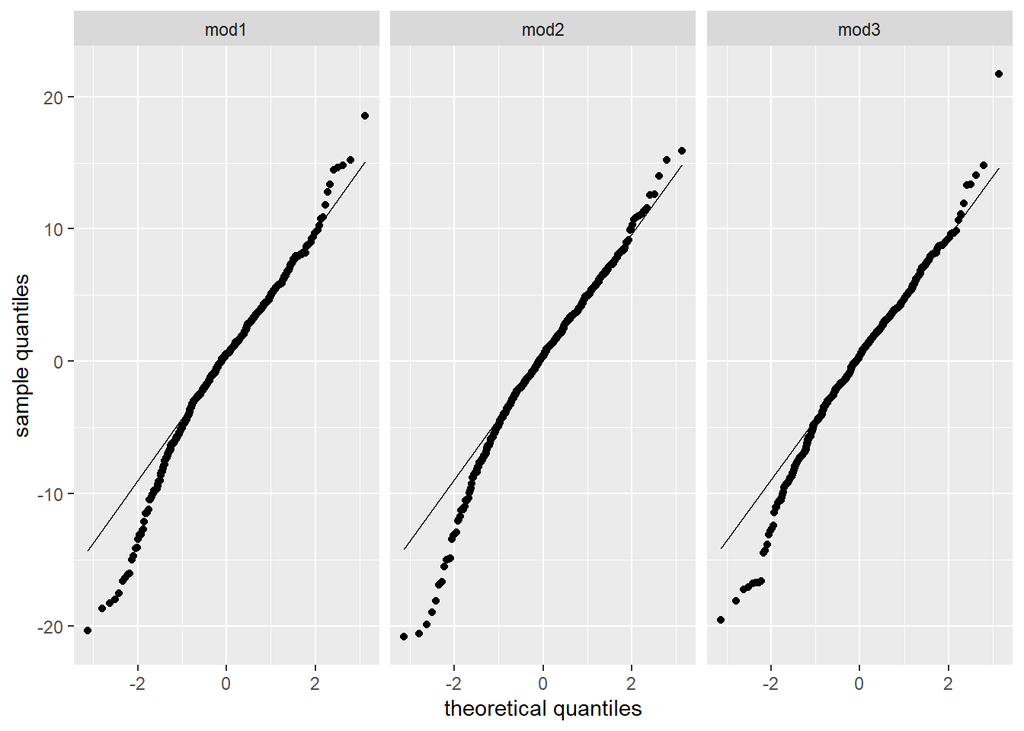

```r
BL_pred %>%
  ggplot(aes(sample = residuals)) +
  stat_qq() + stat_qq_line() + facet_grid(~ model) +
  labs(x = "theoretical quantiles", y = "sample quantiles")
```

# Sustainable development goals (SDG) data

```r
sdg <- read_csv("https://people.bath.ac.uk/kai21/MA50258/data/sdg.csv")
```

From the plot, I transformed IMR to log2 scale and then plot Loess fit and transformed linear relationship, I found Loess fit and Transformed linear fit have quite good agreement.

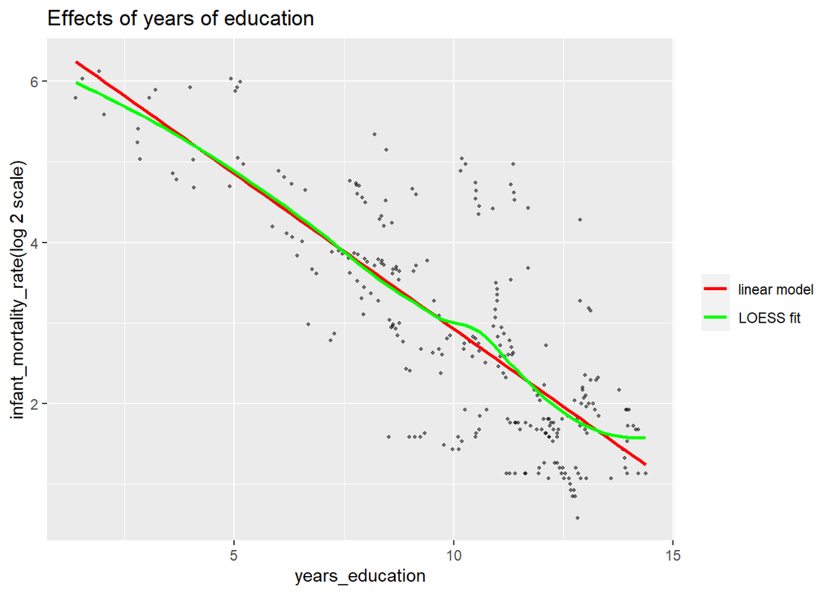

```r
# transform the MIR, I got linear relationship with year_education
sdg %>%
  ggplot(
      aes(x =years_education,
          y = log2(infant_mortality_rate))) +
    geom_point(alpha = 0.5,
               size  = 0.8)+
      geom_smooth(aes(col = "linear model"),
                  method  = "lm",
                  se = F,
                  linewidth = 1) +
  geom_smooth(aes(col = "LOESS fit"),
                  method  = "loess",
                  se = F,
                  linewidth = 1) +
        labs(x = "years_education",
             y = "infant_mortality_rate(log 2 scale)",
             title="Effects of years of education")+
          scale_colour_manual("",
                              values = c("linear model"= "red", "LOESS fit" = "green"))
```

From this boxplot, I found year does not have significant effect on IMR, so I won’t include year in my model.

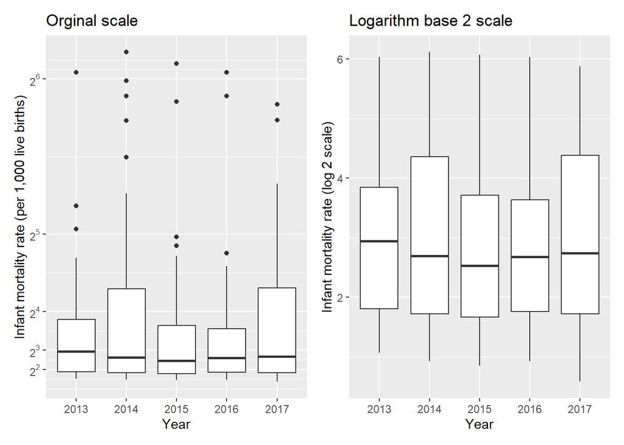

```r
box_plot_imr <-
sdg %>%
  mutate(year = factor(year)) %>%
  ggplot(aes(x = year,
             y = infant_mortality_rate)) +
    geom_boxplot() +
      labs(x = "Year",
           y = "Infant mortality rate (per 1,000 live births)",
           title = "Orginal scale") +
        scale_y_continuous(breaks = 2^(2:6),
                           labels = label_log(base = 2))

box_plot_log2_imr <-
sdg %>%
  mutate(year = factor(year)) %>%
  ggplot(aes(x = year,
             y = log2(infant_mortality_rate))) +
    geom_boxplot() +
      labs(x = "Year",
           y = "Infant mortality rate (log 2 scale)",
           title = "Logarithm base 2 scale")


library(patchwork)
box_plot_imr |box_plot_log2_imr
```

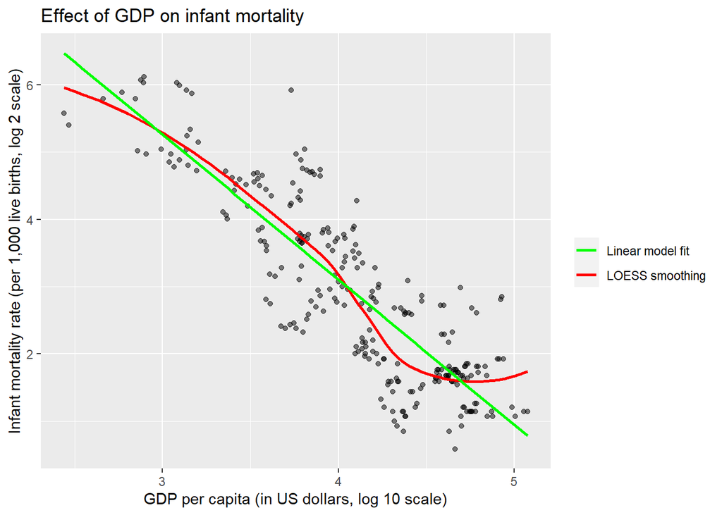

```r
sdg %>%
  ggplot(aes(x = log10(gdp), y = log2(infant_mortality_rate))) +
  geom_point(alpha = 0.5) +
  geom_smooth(aes(col = "LOESS smoothing"),
              method = "loess",
              se = F,
              formula = y ~ x,
              linewidth = 1) +
  geom_smooth(aes(col = "Linear model fit"),
              method = "lm",
              se = F,
              formula = y ~ x,
              linewidth =1) +
  labs(x = "GDP per capita (in US dollars, log 10 scale)",
       y = "Infant mortality rate (per 1,000 live births, log 2 scale)",
       title = "Effect of GDP on infant mortality")+
  scale_color_manual("",
                     values = c("LOESS smoothing" = "red",
                                "Linear model fit" = "green"))
```

This plot shows some pattern between IMR and income class, The higher income, the lower IMR

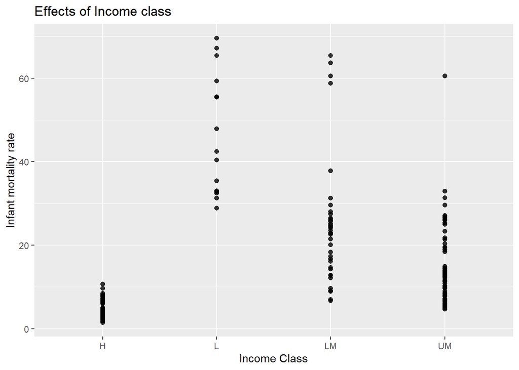

```r
 sdg %>%
  ggplot(aes(x =income_class,
             y = infant_mortality_rate)) +
    geom_point(alpha = 0.8,
               size  = 1.7)+
        labs(x = "Income Class",
             y = "Infant mortality rate",
             title="Effects of Income class")
```

**analyse interaction by plot**

I will fit separate LOESS for each continent to explore the interactions between continents and GDP, and continents and year_education. from plot below, there is interactions between continents and year education in sense of effects on IMR

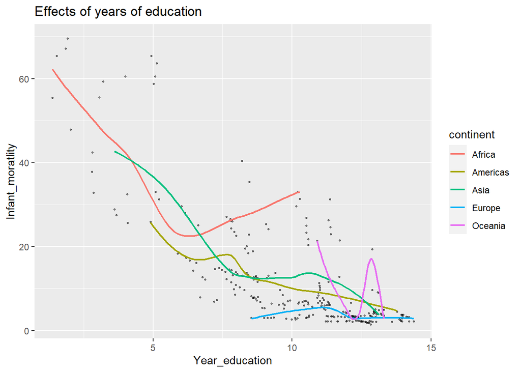

```r
plot_group_by_continent1 <-
  sdg %>%
    mutate(continent = factor(continent)) %>%
      ggplot(aes(x     = years_education,
                 y     = infant_mortality_rate,
                 group = continent)) +
        geom_point(alpha = 0.5,
                   size  = 0.5) +
          geom_smooth(aes(col = continent),
                      method    = "loess",
                      se        = F,
                      formula   = y ~ x,
                      linewidth =0.8) +
                labs(x   = "Year_education",
                     y   = "Infant_moratlity",
                     title="Effects of years of education")

plot_group_by_continent1
```

From plot below, there is interactions between continents and GDP in sense of effects on IMR

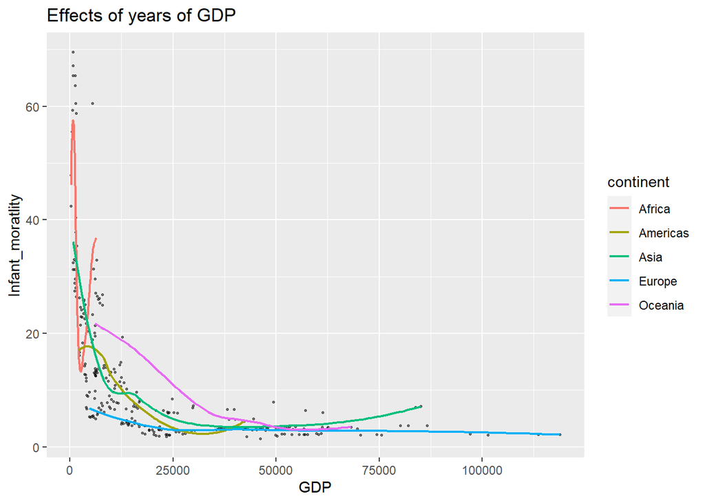

```r
plot_group_by_continent2 <-
  sdg %>%
    mutate(continent = factor(continent)) %>%
      ggplot(aes(x     = gdp,
                 y     = infant_mortality_rate,
                 group = continent)) +
        geom_point(alpha = 0.5,
                   size  = 0.5) +
          geom_smooth(aes(col = continent),
                      method    = "loess",
                      se        = F,
                      formula   = y ~ x,
                      linewidth =0.8) +
                labs(x   = "GDP",
                     y   = "Infant_moratlity",
                     title="Effects of years of GDP")

plot_group_by_continent2
```

**Build Models** The process of build models, I summarize the information above 1. I won’t include year as my predictor 2. there are interaction between continents and GDP, and continents and year education in sense of impacts on IMR 3. log2(IMR) virtually have a linear relationship with year education 4. log(IMR) don’t have strong linear relationship with GDP 5. income class have virtually have significant relationship with IMR, the lower income class, the higher IMR

based on data information above, I try to build some model, i finally get three models that i this best. Model1:
$$E[\log_{2}(\verb|infant_mortarity_rate|)|\verb|years_education|,\log_{10}(\verb|gdp|),\verb|continent|,\verb|income_class|]=\sigma_0
+ \sigma_1\verb|years_education| + \sigma_2\log_{10}(\verb|gdp|) +
\sigma_3\verb|continent|\\ +
\sigma_4\verb|income_class|+\sigma_5\verb|continent|*\verb|income_class|\\
+\sigma_6\verb|years_education|*\verb|continent|*\verb|income_class|$$

Model2:
$$E[\log_{2}(\verb|infant_mortarity_rate|)|\verb|years_education|,\log_{10}(\verb|gdp|),\verb|continent|,\verb|income_class|]=\beta_0
+\beta_1\verb|years_education| + \beta_2\log_{10}(\verb|gdp|) +
\beta_3\verb|continent|\\ +
\beta_4\verb|income_class|+\beta_5\verb|years_education|*\verb|continent|\\+
\beta_6\verb|continent|*\verb|income_class|$$

Model3:
$$E[\log_{2}(\verb|infant_mortarity_rate|)|\verb|years_education|,\log_{10}(\verb|gdp|),\verb|continent|,\verb|income_class|]=\alpha_0
+\alpha_1\verb|continent| + s(\log_{10}(\verb|gdp|)) +
s(\verb|years_education|)$$

There are AIC of three models

```r
model_11<- lm(log2(infant_mortality_rate) ~ years_education + log10(gdp) + continent + income_class + continent*income_class + years_education*continent*income_class,   sdg)

model_22<- lm(log2(infant_mortality_rate) ~years_education + log10(gdp) + continent + income_class + years_education*continent + continent*income_class,   sdg)

model_33 <- gam(log2(infant_mortality_rate) ~ continent+s(years_education,k=4) + s(log10(gdp),k=4),data =sdg)
cat("AIC of Model1:",extractAIC(model_11)[2],"\n")
```

```
## AIC of Model1: -415.378
```

```r
cat("AIC of Model2:",extractAIC(model_22)[2],"\n")
```

```
## AIC of Model2: -396.2321
```

```r
cat("AIC of Model3:",extractAIC(model_33)[2],"\n")
```

```
## AIC of Model3: 405.3097
```

**Hypothesis test**

Hypothesis test for model1
$$H_0:\,
\sigma_0=\sigma_1=\sigma_2=\sigma_3=\sigma_4=\sigma_5=\sigma_6=0\
\qquad \mbox{vs} \qquad H_1:\,\sigma_0\neq 0, \sigma_1\neq
0,\sigma_2\neq 0,\sigma_3\neq 0,\sigma_4\neq
0,\sigma_5\neq0,\sigma_6\neq0$$
From the table of ANOVA, there is F test results, it shows that each coefficient is not equal 0, which means i should reject null hypothesis test above. Each predictors in my model have significant relationship with response variable(IMR)

```r
anova(model_11)
```

```
## Analysis of Variance Table
##
## Response: log2(infant_mortality_rate)
##                                         Df  Sum Sq Mean Sq   F value    Pr(>F)
## years_education                          1 312.576 312.576 1682.3217 < 2.2e-16
## log10(gdp)                               1  83.672  83.672  450.3347 < 2.2e-16
## continent                                4  27.242   6.810   36.6548 < 2.2e-16
## income_class                             3   8.886   2.962   15.9418 1.828e-09
## continent:income_class                   6  11.081   1.847    9.9397 9.013e-10
## years_education:continent                4   3.821   0.955    5.1419 0.0005477
## years_education:income_class             3   3.444   1.148    6.1796 0.0004659
## years_education:continent:income_class   6   3.151   0.525    2.8265 0.0112567
## Residuals                              234  43.477   0.186
##
## years_education                        ***
## log10(gdp)                             ***
## continent                              ***
## income_class                           ***
## continent:income_class                 ***
## years_education:continent              ***
## years_education:income_class           ***
## years_education:continent:income_class *
## Residuals
## ---
## Signif. codes:  0 '***' 0.001 '**' 0.01 '*' 0.05 '.' 0.1 ' ' 1
```

Hypothesis test for model2
$$H_0:\,
\beta_0=\beta_1=\beta_2=\beta_3=\beta_4=\beta_5=\beta_6=0\
\qquad \mbox{vs} \qquad H_1:\,\beta_1\neq 0, \beta_2\neq 0,\beta_3\neq
0,\beta_4\neq 0,\beta_5\neq 0,\beta_6\neq0$$

From the table of ANOVA, there is F test results, it shows that each coefficient is not equal 0, which means i should reject null hypothesis test above. Each predictors in my model have significant relationship with response variable(IMR)

```r
anova(model_22)
```

```
## Analysis of Variance Table
##
## Response: log2(infant_mortality_rate)
##                            Df  Sum Sq Mean Sq   F value    Pr(>F)
## years_education             1 312.576 312.576 1516.9110 < 2.2e-16 ***
## log10(gdp)                  1  83.672  83.672  406.0564 < 2.2e-16 ***
## continent                   4  27.242   6.810   33.0508 < 2.2e-16 ***
## income_class                3   8.886   2.962   14.3744 1.188e-08 ***
## years_education:continent   4   7.904   1.976    9.5894 3.243e-07 ***
## continent:income_class      6   6.998   1.166    5.6604 1.598e-05 ***
## Residuals                 243  50.073   0.206
## ---
## Signif. codes:  0 '***' 0.001 '**' 0.01 '*' 0.05 '.' 0.1 ' ' 1
```

Coefficient table for model2

```r
summary(model_22)
```

```
##
## Call:
## lm(formula = log2(infant_mortality_rate) ~ years_education +
##     log10(gdp) + continent + income_class + years_education *
##     continent + continent * income_class, data = sdg)
##
## Residuals:
##      Min       1Q   Median       3Q      Max
## -1.20022 -0.24591  0.00901  0.24150  1.16925
##
## Coefficients: (6 not defined because of singularities)
##                                   Estimate Std. Error t value Pr(>|t|)
## (Intercept)                        6.98872    0.85291   8.194 1.45e-14 ***
## years_education                   -0.09693    0.04525  -2.142 0.033185 *
## log10(gdp)                        -0.78125    0.14802  -5.278 2.90e-07 ***
## continentAmericas                  0.27337    0.85482   0.320 0.749394
## continentAsia                      0.52728    0.65489   0.805 0.421529
## continentEurope                   -1.74371    0.73266  -2.380 0.018086 *
## continentOceania                  -4.45355    2.81525  -1.582 0.114964
## income_classL                      1.17455    0.56957   2.062 0.040254 *
## income_classLM                     0.61527    0.56608   1.087 0.278154
## income_classUM                     2.00164    0.41202   4.858 2.12e-06 ***
## years_education:continentAmericas -0.01585    0.07427  -0.213 0.831156
## years_education:continentAsia     -0.07596    0.05058  -1.502 0.134447
## years_education:continentEurope    0.09079    0.05639   1.610 0.108685
## years_education:continentOceania   0.34024    0.23640   1.439 0.151361
## continentAmericas:income_classL         NA         NA      NA       NA
## continentAsia:income_classL       -0.25251    0.60428  -0.418 0.676408
## continentEurope:income_classL           NA         NA      NA       NA
## continentOceania:income_classL          NA         NA      NA       NA
## continentAmericas:income_classLM  -0.28094    0.62298  -0.451 0.652421
## continentAsia:income_classLM       0.46347    0.56509   0.820 0.412928
## continentEurope:income_classLM          NA         NA      NA       NA
## continentOceania:income_classLM         NA         NA      NA       NA
## continentAmericas:income_classUM  -1.44645    0.44292  -3.266 0.001249 **
## continentAsia:income_classUM      -1.08216    0.42435  -2.550 0.011382 *
## continentEurope:income_classUM    -1.50372    0.41606  -3.614 0.000366 ***
## continentOceania:income_classUM         NA         NA      NA       NA
## ---
## Signif. codes:  0 '***' 0.001 '**' 0.01 '*' 0.05 '.' 0.1 ' ' 1
##
## Residual standard error: 0.4539 on 243 degrees of freedom
##   (因为不存在，5个观察量被删除了)
## Multiple R-squared:  0.8993, Adjusted R-squared:  0.8914
## F-statistic: 114.2 on 19 and 243 DF,  p-value: < 2.2e-16
```

Hypothesis test for model3
$$H_0:\,
s(\log_{10}(\verb|gdp|))=0,s(\verb|years_education|)=0\
\qquad \mbox{vs} \qquad H_1:\, s(\log_{10}(\verb|gdp|)) \neq
0,s(\verb|years_education|)\neq 0$$

From the table of ANOVA, the results are that I should reject null hypothesis test, The smoothers, s(log10(gdp)) and s(year_education), have a obvious relationship with IMR

```r
anova(model_33)
```

```
##
## Family: gaussian
## Link function: identity
##
## Formula:
## log2(infant_mortality_rate) ~ continent + s(years_education,
##     k = 4) + s(log10(gdp), k = 4)
##
## Parametric Terms:
##           df     F  p-value
## continent  4 21.31 3.59e-15
##
## Approximate significance of smooth terms:
##                      edf Ref.df     F  p-value
## s(years_education) 1.000  1.000 23.36 2.68e-06
## s(log10(gdp))      2.947  2.998 91.29  < 2e-16
```

Coefficient table for model3

```r
summary(model_33)
```

```
##
## Family: gaussian
## Link function: identity
##
## Formula:
## log2(infant_mortality_rate) ~ continent + s(years_education,
##     k = 4) + s(log10(gdp), k = 4)
##
## Parametric coefficients:
##                   Estimate Std. Error t value Pr(>|t|)
## (Intercept)         3.6434     0.1579  23.076  < 2e-16 ***
## continentAmericas  -0.4274     0.1751  -2.442  0.01530 *
## continentAsia      -0.5327     0.1625  -3.278  0.00119 **
## continentEurope    -1.1770     0.1840  -6.397 7.56e-10 ***
## continentOceania   -0.3712     0.2441  -1.521  0.12958
## ---
## Signif. codes:  0 '***' 0.001 '**' 0.01 '*' 0.05 '.' 0.1 ' ' 1
##
## Approximate significance of smooth terms:
##                      edf Ref.df     F  p-value
## s(years_education) 1.000  1.000 23.36 2.68e-06 ***
## s(log10(gdp))      2.947  2.998 91.29  < 2e-16 ***
## ---
## Signif. codes:  0 '***' 0.001 '**' 0.01 '*' 0.05 '.' 0.1 ' ' 1
##
## R-sq.(adj) =  0.862   Deviance explained = 86.6%
## GCV = 0.27166  Scale est. = 0.26242   n = 263
```

```r
sdg_fv <- sdg %>%
                gather_predictions(model_11,
                                   model_22,
                                   model_33,
                                   .model = "model",
                                   .pred  = "fitted_vals",
                                   type   = "response")
sdg_resid <- sdg %>%
                    gather_residuals(model_11,
                                     model_22,
                                     model_33,
                                     .model = "model",
                                     .resid = "residuals")
```

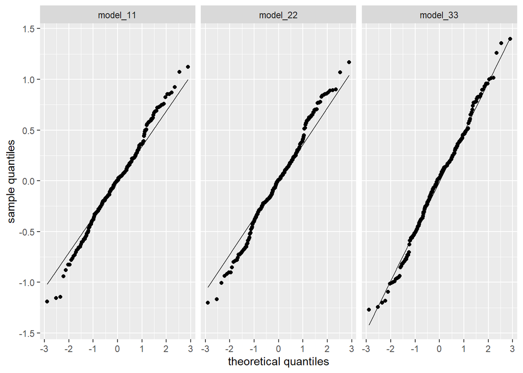

```r
sdg_resid %>%
  ggplot(aes(sample = residuals)) +
  stat_qq() + stat_qq_line() + facet_grid(~ model) +
  labs(x = "theoretical quantiles", y = "sample quantiles")
```

# References

1. Wickham, H. *ggplot2: Elegant Graphics for Data Analysis* [on-line version](https://ggplot2-book.org/index.html)
2. Wickham, H. & Grolemund, G. *R for Data Science.* [on-line version](https://r4ds.had.co.nz/index.html)
3. [Department of Maths website](https://www.bath.ac.uk/departments/department-of-mathematical-sciences/)